## **Input into eV2CG**

Completed at Mon Apr 18 22:43:53 2022 (Asia/Shanghai), with the runtime of 68 seconds on the server side (not including the runtime on the client/user side).

> **An interactive table** of user-input SNPs, with 1st column `SNPs` for dbSNP rsIDs, 2nd column `P-values` for significance info.

| SNPs | P-values |
| --- | --- |
| rs11190133 | 6e-09 |
| rs10743181 | 2e-08 |
| rs11229555 | 4e-08 |
| rs11230563 | 5e-15 |
| rs174535 | 2e-11 |
| rs559928 | 8e-14 |
| rs568617 | 4e-08 |
| rs11236797 | 3e-43 |
| rs7115956 | 8e-12 |
| rs4561177 | 1e-09 |

[output cut: 214 more lines]

## **Output: core genes**

> **Manhattan plot** illustrates scored core genes color-coded by chromosomes, with the top 30 genes labelled. Also provided is an editable PDF file for download.

Download PDF

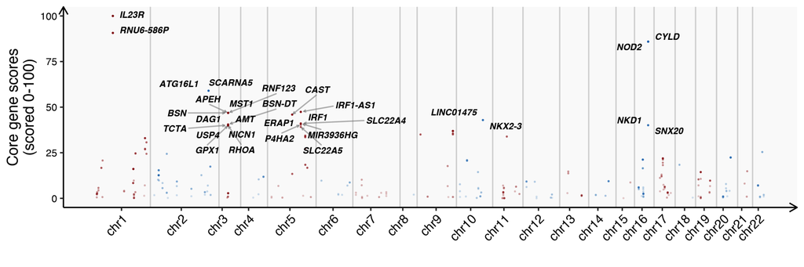

Figure 1: Manhattan plot illustrating scores (y-axis) for core genes (color-coded by chromosomes; x-axis), with the top scored genes labelled.

> **An interactive table** of core genes linked from the input SNPs, with the column `Scores` quantifying the degree of genes responsible for genetic associations (capped at 100). `Core genes` are cross-referenced and hyperlinked to [GeneCards](https://www.genecards.org). Also provided is the column `Evidence` used to define core genes; please refer to **`Evidence table`** for details.

[output not shown]

[output cut: 400 more lines]

> **Evidence table** for core genes, showing which SNPs (see the column `SNPs`) are used to define core genes (the column `Core genes`) based on which evidence (see the column `Evidence`). The column `SNP type` tells the SNP type (either `Input` for use-input SNPs or `LD` for LD SNPs). Notably, the column `Evidence` details datasets used: the prefix `Proximity_` indicative of SNPs in the proximity, the prefix `PCHiC_` for PCHi-C datasets, and the prefix `QTL_` for e/pQTL datasets.

| Core genes | SNPs | SNP type | Evidence |
| --- | --- | --- | --- |
| IL23R | rs10889676 | Input | Proximity_20000bp |
| IL23R | rs183686347 | Input | Proximity_20000bp |
| IL23R | rs7517847 | Input | Proximity_20000bp |
| IL23R | rs80174646 | Input | Proximity_20000bp |
| IL23R | rs1004820 | LD | Proximity_20000bp |
| IL23R | rs10789230 | LD | Proximity_20000bp |
| IL23R | rs10889673 | LD | Proximity_20000bp |
| IL23R | rs10889677 | LD | Proximity_20000bp |
| IL23R | rs111379368 | LD | Proximity_20000bp |
| IL23R | rs11209026 | LD | Proximity_20000bp |

[output cut: 5968 more lines]